# Untitled

Brian A. Fannin

October 19, 2017

# What is the likelihood of a second accident?

# The data

# Example - NFL arrests

## Before anyone gets carried away…

From nflarrests.com:

> Keep in mind there are 1700 NFL Players and their arrest rates are lower than the USA arrest rate.

Also: arrest != conviction

- Rate of 1st arrest requires player statistics for each season, requires a second source.
- I’m lazy. Let’s check rate of second arrest.
- Number of players who’ve been arrested: 642
- Number of arrests: 858
- Number of players w/more than one arrest: 145

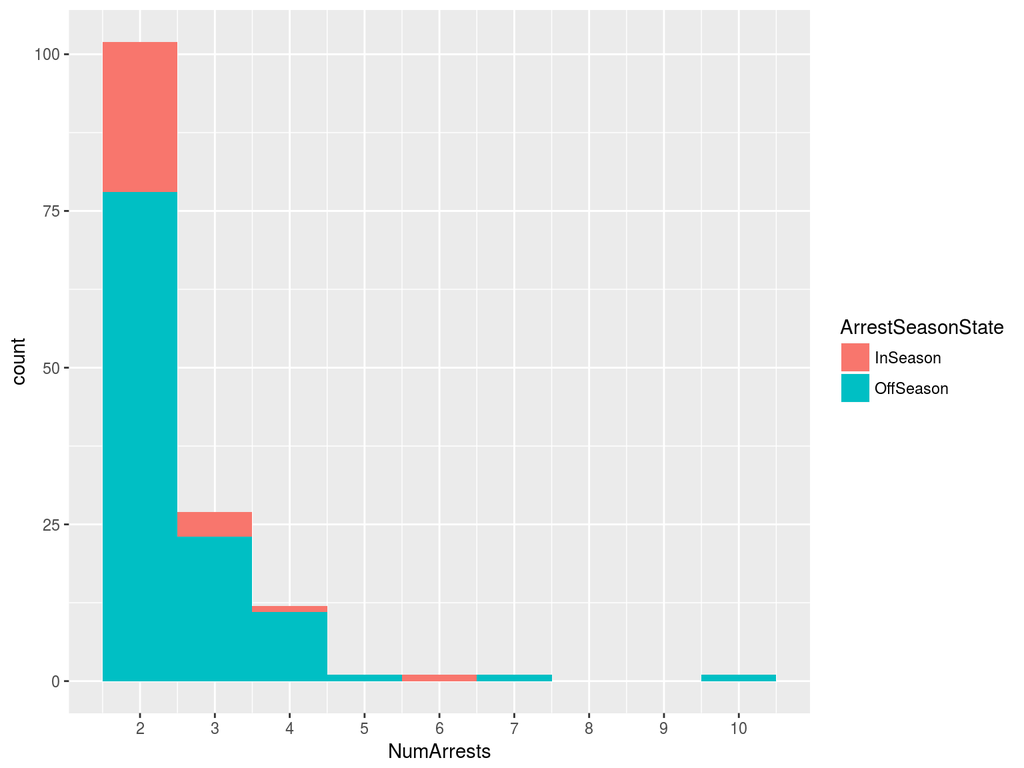

So there is a small probability of having more than one arrest. Compare this to Bailey/Simon probability of second accident.

# A decision tree

## Characteristics of a decision tree

- Divides a sample into categories
- The ‘prediction’ is a function of some value within each category
- Membership is assessed by computing some criteria. If a split improves the criteria, then it is made. Forward only, i.e. ‘greedy’.
- Number of levels and other criteria control the size and shape of the tree
- In this case, output is discrete and binary. Continuous response will produce a finite set of predictions.

## First attempt

Decision trees

## About the data

- Must ensure that character variables are factors
- Create one hot encoded columns
- Weirdly, one hot encoding doesn’t appear to work with `rpart()`

## Random forests

- Boosts

## Naive Bayes

- Often used in text processing
- Great for a sparse matrix

# Conclusion

## Thank you!

## References

# Flotsam